# Exploratory Data Analysis in R: Case Study

William Surles

2017-08-014

# Introduction

- Course notes from the [Exploratory Data Analysis in R: Case Study](https://www.datacamp.com/courses/exploratory-data-analysis-in-r-case-study) course on DataCamp

## Whats Covered

- Data cleaning and summarizing with dplyr
- Data visualization with ggplot2
- Tidy modeling with broom
- Joining and tidying

## Libraries and Data

```r
library(dplyr)
library(tidyr)
library(purrr)
library(ggplot2)
library(broom)
library(countrycode)
library(stringr)
library(data.table)

votes <- readRDS('data/votes.rds')
descriptions <- readRDS('data/descriptions.rds')
```

# Data cleaning and summarizing with dplyr

## The United Nations voting dataset

### – Filtering rows

- 1 = Yes
- 2 = Abstain
- 3 = No
- 8 = Not present
- 9 = Not a member

```r
# Load the dplyr package

# Print the votes dataset
votes
```

```
## # A tibble: 508,929 x 4
##     rcid session  vote ccode
##    <dbl>   <dbl> <dbl> <int>
##  1    46       2     1     2
##  2    46       2     1    20
##  3    46       2     9    31
##  4    46       2     1    40
##  5    46       2     1    41
##  6    46       2     1    42
##  7    46       2     9    51
##  8    46       2     9    52
##  9    46       2     9    53
## 10    46       2     9    54
## # ... with 508,919 more rows
```

```r
# Filter for votes that are "yes", "abstain", or "no"
votes %>%
  filter(vote <= 3)
```

```
## # A tibble: 353,547 x 4
##     rcid session  vote ccode
##    <dbl>   <dbl> <dbl> <int>
##  1    46       2     1     2
##  2    46       2     1    20
##  3    46       2     1    40
##  4    46       2     1    41
##  5    46       2     1    42
##  6    46       2     1    70
##  7    46       2     1    90
##  8    46       2     1    91
##  9    46       2     1    92
## 10    46       2     1    93
## # ... with 353,537 more rows
```

### – Adding a year column

- first session was in 1946. That is session 1.
- There is one session per year.
- So, `year = session + 1945`

```r
# Add another %>% step to add a year column
votes %>%
  filter(vote <= 3) %>%
  mutate(year = session + 1945)
```

```
## # A tibble: 353,547 x 5
##     rcid session  vote ccode  year
##    <dbl>   <dbl> <dbl> <int> <dbl>
##  1    46       2     1     2  1947
##  2    46       2     1    20  1947
##  3    46       2     1    40  1947
##  4    46       2     1    41  1947
##  5    46       2     1    42  1947
##  6    46       2     1    70  1947
##  7    46       2     1    90  1947
##  8    46       2     1    91  1947
##  9    46       2     1    92  1947
## 10    46       2     1    93  1947
## # ... with 353,537 more rows
```

### – Adding a country column

- The class country codes had the “United States” for some reason
- I need to drop “of America” from the country code here so the class code works for the rest of the doc

```r
# Load the countrycode package

# Convert country code 100
countrycode(100, "cown", "country.name")
```

```
## [1] "Colombia"
```

```r
# Add a country column within the mutate: votes_processed
votes_processed <- votes %>%
  filter(vote <= 3) %>%
  mutate(
    year = session + 1945,
    country = countrycode(ccode, "cown", "country.name"),
    country = recode(country,
                     'United States of America' =  'United States',
                     'United Kingdom of Great Britain and Northern Ireland' = 'United Kingdom')
    )
```

## Grouping and summarizing

### – Summarizing the full dataset

```r
# Print votes_processed
votes_processed
```

```
## # A tibble: 353,547 x 6
##     rcid session  vote ccode  year            country
##    <dbl>   <dbl> <dbl> <int> <dbl>              <chr>
##  1    46       2     1     2  1947      United States
##  2    46       2     1    20  1947             Canada
##  3    46       2     1    40  1947               Cuba
##  4    46       2     1    41  1947              Haiti
##  5    46       2     1    42  1947 Dominican Republic
##  6    46       2     1    70  1947             Mexico
##  7    46       2     1    90  1947          Guatemala
##  8    46       2     1    91  1947           Honduras
##  9    46       2     1    92  1947        El Salvador
## 10    46       2     1    93  1947          Nicaragua
## # ... with 353,537 more rows
```

```r
# Find total and fraction of "yes" votes
votes_processed %>%
  summarise(
    total = n(),
    percent_yes = mean(vote == 1)
    )
```

```
## # A tibble: 1 x 2
##    total percent_yes
##    <int>       <dbl>
## 1 353547   0.7999248
```

### – Summarizing by year

```r
# Change this code to summarize by year
votes_processed %>%
  group_by(year) %>%
  summarize(total = n(),
            percent_yes = mean(vote == 1))
```

```
## # A tibble: 34 x 3
##     year total percent_yes
##    <dbl> <int>       <dbl>
##  1  1947  2039   0.5693968
##  2  1949  3469   0.4375901
##  3  1951  1434   0.5850767
##  4  1953  1537   0.6317502
##  5  1955  2169   0.6947902
##  6  1957  2708   0.6085672
##  7  1959  4326   0.5880721
##  8  1961  7482   0.5729751
##  9  1963  3308   0.7294438
## 10  1965  4382   0.7078959
## # ... with 24 more rows
```

### – Summarizing by country

```r
# Summarize by country: by_country
by_country <- votes_processed %>%
  group_by(country) %>%
  summarize(total = n(),
            percent_yes = mean(vote == 1))

by_country
```

```
## # A tibble: 200 x 3
##                country total percent_yes
##                  <chr> <int>       <dbl>
##  1         Afghanistan  2373   0.8592499
##  2             Albania  1695   0.7174041
##  3             Algeria  2213   0.8992318
##  4             Andorra   719   0.6383866
##  5              Angola  1431   0.9238295
##  6 Antigua and Barbuda  1302   0.9124424
##  7           Argentina  2553   0.7677242
##  8             Armenia   758   0.7467018
##  9           Australia  2575   0.5565049
## 10             Austria  2389   0.6224362
## # ... with 190 more rows
```

## Sorting and filtering summarized data

### – Sorting by percentage of “yes” votes

```r
# You have the votes summarized by country
by_country <- votes_processed %>%
  group_by(country) %>%
  summarize(total = n(),
            percent_yes = mean(vote == 1))

# Print the by_country dataset
by_country
```

```
## # A tibble: 200 x 3
##                country total percent_yes
##                  <chr> <int>       <dbl>
##  1         Afghanistan  2373   0.8592499
##  2             Albania  1695   0.7174041
##  3             Algeria  2213   0.8992318
##  4             Andorra   719   0.6383866
##  5              Angola  1431   0.9238295
##  6 Antigua and Barbuda  1302   0.9124424
##  7           Argentina  2553   0.7677242
##  8             Armenia   758   0.7467018
##  9           Australia  2575   0.5565049
## 10             Austria  2389   0.6224362
## # ... with 190 more rows
```

```r
# Sort in ascending order of percent_yes
by_country %>%
  arrange(percent_yes)
```

```
## # A tibble: 200 x 3
##                             country total percent_yes
##                               <chr> <int>       <dbl>
##  1                         Zanzibar     2   0.0000000
##  2                    United States  2568   0.2694704
##  3                            Palau   369   0.3387534
##  4                           Israel  2380   0.3407563
##  5      Federal Republic of Germany  1075   0.3972093
##  6                   United Kingdom  2558   0.4167318
##  7                           France  2527   0.4265928
##  8 Micronesia (Federated States of)   724   0.4419890
##  9                 Marshall Islands   757   0.4914135
## 10                          Belgium  2568   0.4922118
## # ... with 190 more rows
```

```r
# Now sort in descending order
by_country %>%
  arrange(desc(percent_yes))
```

```
## # A tibble: 200 x 3
##                  country total percent_yes
##                    <chr> <int>       <dbl>
##  1 Sao Tome and Principe  1091   0.9761687
##  2            Seychelles   881   0.9750284
##  3              Djibouti  1598   0.9612015
##  4         Guinea Bissau  1538   0.9603381
##  5           Timor-Leste   326   0.9570552
##  6             Mauritius  1831   0.9497542
##  7              Zimbabwe  1361   0.9493020
##  8               Comoros  1133   0.9470432
##  9  United Arab Emirates  1934   0.9467425
## 10            Mozambique  1701   0.9465021
## # ... with 190 more rows
```

### – Filtering summarized output

```r
# Filter out countries with fewer than 100 votes
by_country %>%
  arrange(percent_yes) %>%
  filter(total >= 100)
```

```
## # A tibble: 197 x 3
##                             country total percent_yes
##                               <chr> <int>       <dbl>
##  1                    United States  2568   0.2694704
##  2                            Palau   369   0.3387534
##  3                           Israel  2380   0.3407563
##  4      Federal Republic of Germany  1075   0.3972093
##  5                   United Kingdom  2558   0.4167318
##  6                           France  2527   0.4265928
##  7 Micronesia (Federated States of)   724   0.4419890
##  8                 Marshall Islands   757   0.4914135
##  9                          Belgium  2568   0.4922118
## 10                           Canada  2576   0.5081522
## # ... with 187 more rows
```

# Data visualization with ggplot2

## Visualization with ggplot2

### – Plotting a line over time

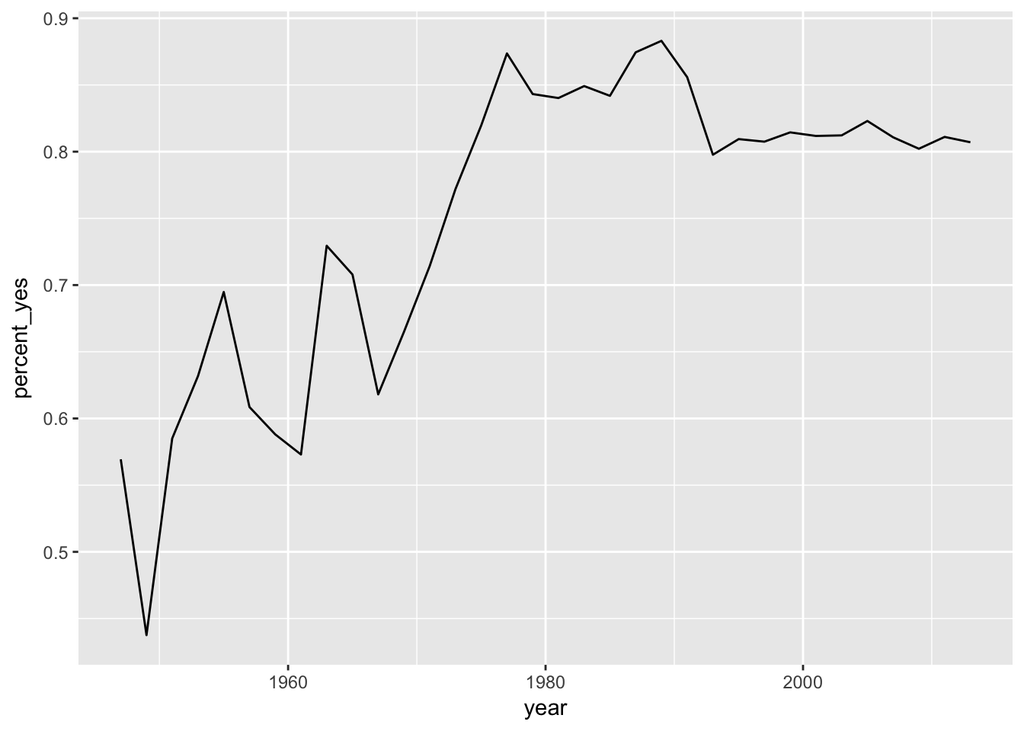

```r
# Define by_year
by_year <- votes_processed %>%
  group_by(year) %>%
  summarize(total = n(),
            percent_yes = mean(vote == 1))

# Load the ggplot2 package
library(ggplot2)

# Create line plot
ggplot(by_year, aes(x = year, y = percent_yes)) +
  geom_line()
```

### – Other ggplot2 layers

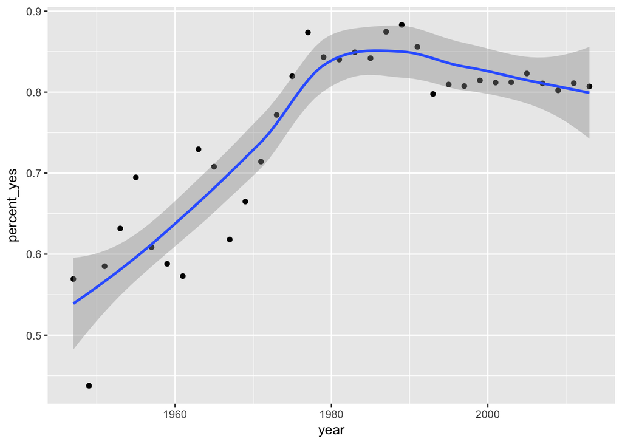

```r
# Change to scatter plot and add smoothing curve
ggplot(by_year, aes(year, percent_yes)) +
  geom_point() +
  geom_smooth()
```

## Visualizing by country

### – Summarizing by year and country

```r
# Group by year and country: by_year_country
by_year_country <- votes_processed %>%
  group_by(year, country) %>%
  summarize(total = n(),
            percent_yes = mean(vote == 1))
```

### – Plotting just the UK over time

```r
# Start with by_year_country dataset
by_year_country <- votes_processed %>%
  group_by(year, country) %>%
  summarize(total = n(),
            percent_yes = mean(vote == 1))

# Print by_year_country
by_year_country
```

```
## # A tibble: 4,744 x 4
## # Groups:   year [?]
##     year                          country total percent_yes
##    <dbl>                            <chr> <int>       <dbl>
##  1  1947                      Afghanistan    34   0.3823529
##  2  1947                        Argentina    38   0.5789474
##  3  1947                        Australia    38   0.5526316
##  4  1947                          Belarus    38   0.5000000
##  5  1947                          Belgium    38   0.6052632
##  6  1947 Bolivia (Plurinational State of)    37   0.5945946
##  7  1947                           Brazil    38   0.6578947
##  8  1947                           Canada    38   0.6052632
##  9  1947                            Chile    38   0.6578947
## 10  1947                         Colombia    35   0.5428571
## # ... with 4,734 more rows
```

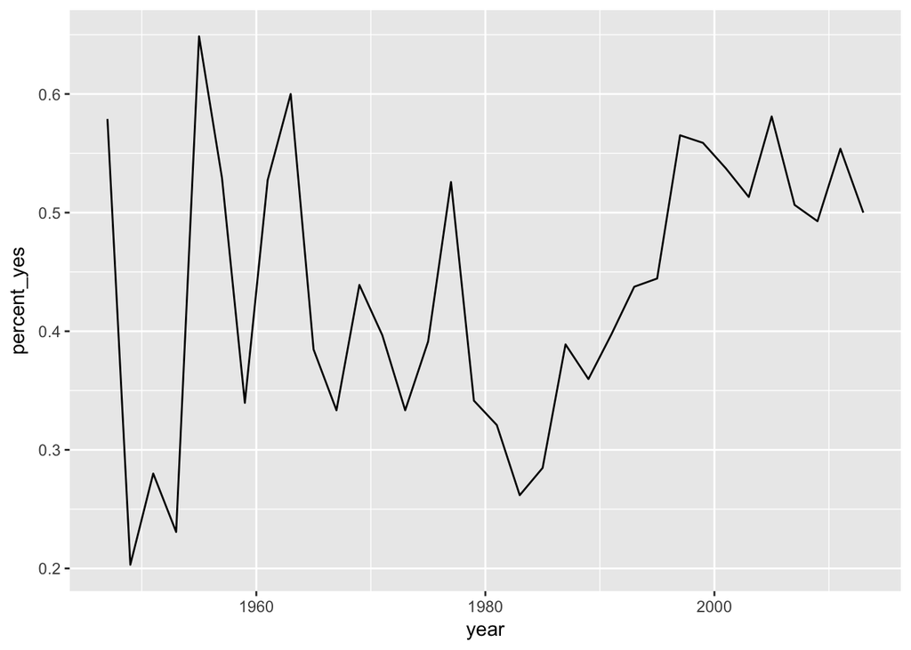

```r
# Create a filtered version: UK_by_year
UK_by_year <- by_year_country %>%
  filter(country == 'United Kingdom')

# Line plot of percent_yes over time for UK only
ggplot(UK_by_year, aes(x = year, y = percent_yes)) +
  geom_line()
```

### – Plotting multiple countries

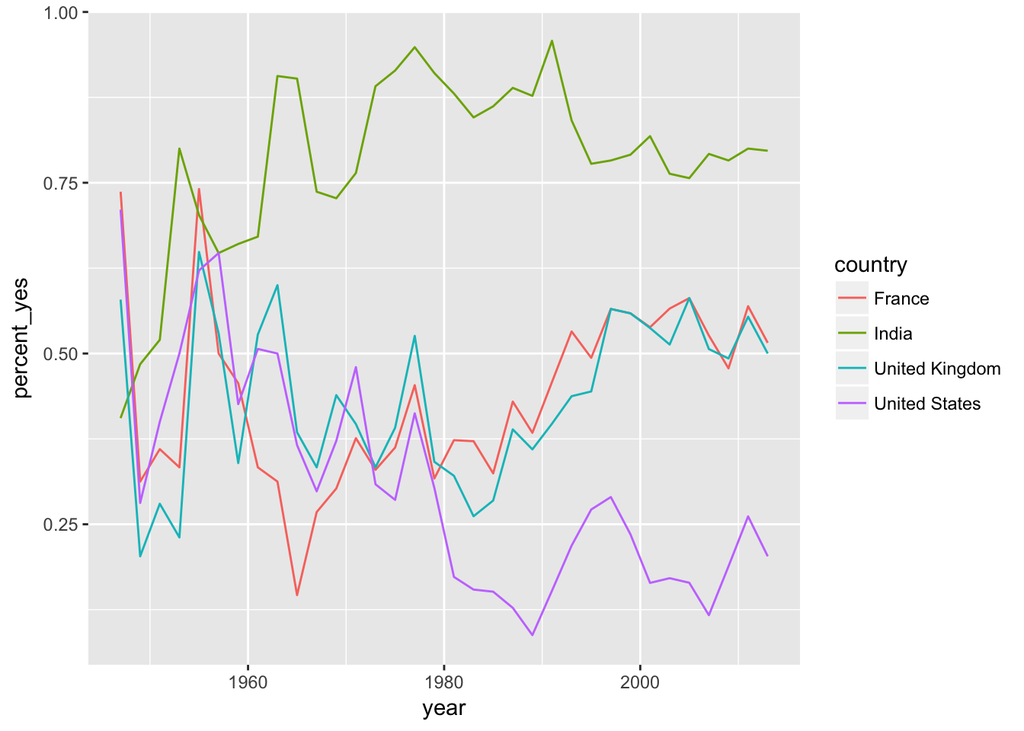

```r
# Vector of four countries to examine
countries <- c("United States", "United Kingdom",
               "France", "India")

# Filter by_year_country: filtered_4_countries
filtered_4_countries <- by_year_country %>%
  filter(country %in% countries)

# Line plot of % yes in four countries
ggplot(filtered_4_countries, aes(x = year, y = percent_yes, color = country)) +
  geom_line()
```

## Faceting

### – Faceting by country

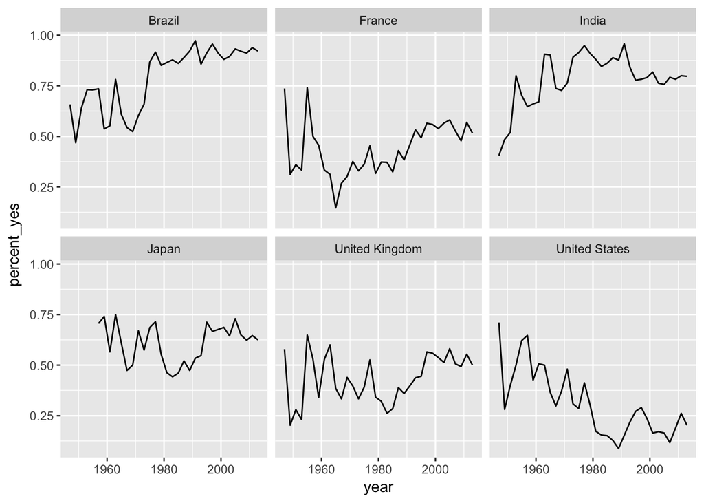

```r
# Vector of six countries to examine
countries <- c("United States", "United Kingdom",
               "France", "Japan", "Brazil", "India")

# Filtered by_year_country: filtered_6_countries
filtered_6_countries <- by_year_country %>%
  filter(country %in% countries)

# Line plot of % yes over time faceted by country
ggplot(filtered_6_countries, aes(x = year, y = percent_yes)) +
  geom_line() +
  facet_wrap(~ country)
```

### – Faceting with free y-axis

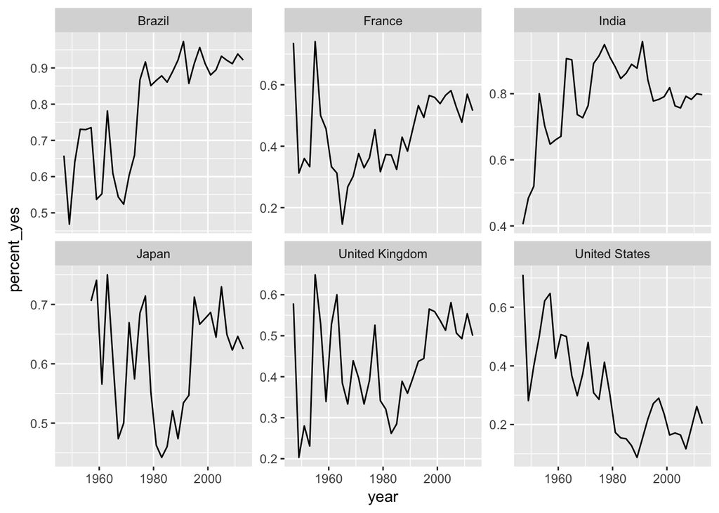

```r
# Vector of six countries to examine
countries <- c("United States", "United Kingdom",
               "France", "Japan", "Brazil", "India")

# Filtered by_year_country: filtered_6_countries
filtered_6_countries <- by_year_country %>%
  filter(country %in% countries)

# Line plot of % yes over time faceted by country
ggplot(filtered_6_countries, aes(year, percent_yes)) +
  geom_line() +
  facet_wrap(~ country, scales = "free_y")
```

### – Choose your own countries

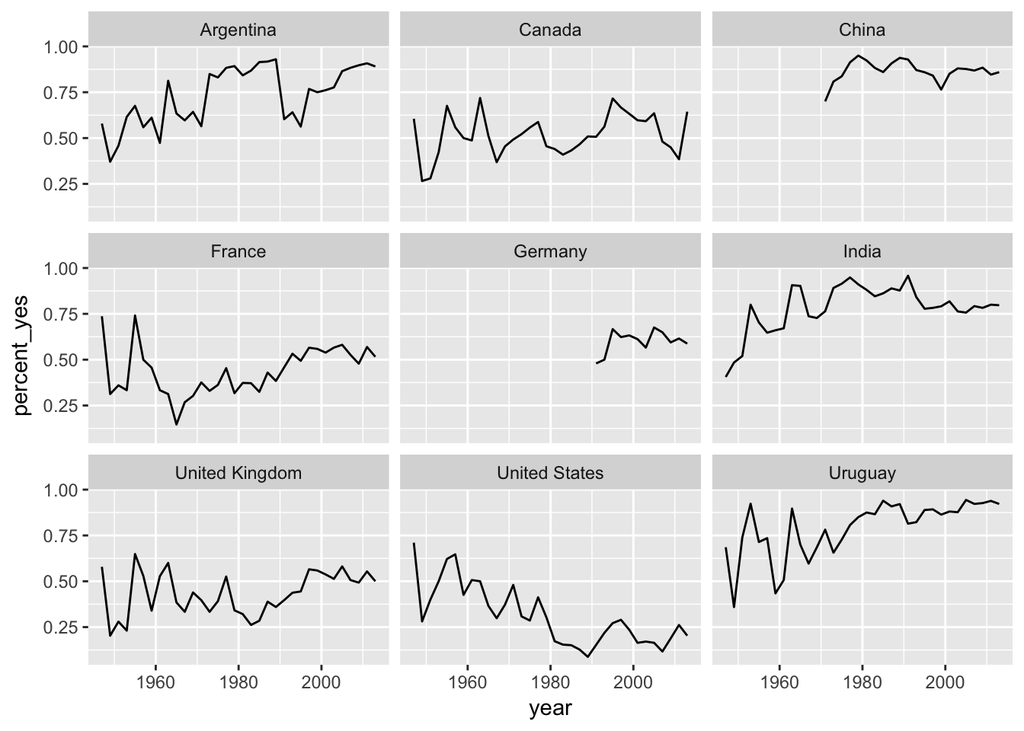

```r
# Add three more countries to this list
countries <- c("United States", "United Kingdom",
               "France", "Germany", "China", "India", "Argentina", "Canada","Uruguay")

# Filtered by_year_country: filtered_countries
filtered_countries <- by_year_country %>%
  filter(country %in% countries)

# Line plot of % yes over time faceted by country
ggplot(filtered_countries, aes(year, percent_yes)) +
  geom_line() +
  facet_wrap(~ country)
```

# Tidy modeling with broom

## Linear regression

> Visualization can surprise you, but it doesn’t scale well. Modeling scales well, but it can’t surprise you. - Hadley Wickham

### – Linear regression on the United States

```r
# Percentage of yes votes from the US by year: US_by_year
US_by_year <- by_year_country %>%
  filter(country == "United States")

# Print the US_by_year data
US_by_year
```

```
## # A tibble: 34 x 4
## # Groups:   year [34]
##     year       country total percent_yes
##    <dbl>         <chr> <int>       <dbl>
##  1  1947 United States    38   0.7105263
##  2  1949 United States    64   0.2812500
##  3  1951 United States    25   0.4000000
##  4  1953 United States    26   0.5000000
##  5  1955 United States    37   0.6216216
##  6  1957 United States    34   0.6470588
##  7  1959 United States    54   0.4259259
##  8  1961 United States    75   0.5066667
##  9  1963 United States    32   0.5000000
## 10  1965 United States    41   0.3658537
## # ... with 24 more rows
```

```r
# Perform a linear regression of percent_yes by year: US_fit
US_fit <- lm(percent_yes ~ year, data = US_by_year)

# Perform summary() on the US_fit object
summary(US_fit)
```

```
##
## Call:
## lm(formula = percent_yes ~ year, data = US_by_year)
##
## Residuals:
##       Min        1Q    Median        3Q       Max
## -0.222491 -0.080635 -0.008661  0.081948  0.194307
##
## Coefficients:
##               Estimate Std. Error t value Pr(>|t|)
## (Intercept) 12.6641455  1.8379743   6.890 8.48e-08 ***
## year        -0.0062393  0.0009282  -6.722 1.37e-07 ***
## ---
## Signif. codes:  0 '***' 0.001 '**' 0.01 '*' 0.05 '.' 0.1 ' ' 1
##
## Residual standard error: 0.1062 on 32 degrees of freedom
## Multiple R-squared:  0.5854, Adjusted R-squared:  0.5724
## F-statistic: 45.18 on 1 and 32 DF,  p-value: 1.367e-07
```

### – Finding the p-value of a linear regression

- In this linear model, what is the p-value of the relationship between year and percent_yes?
  - 1.37e-07

## Tidying models with broom

### – Tidying a linear regression model

```r
# Load the broom package

# Call the tidy() function on the US_fit object
tidy(US_fit)
```

```
##          term     estimate    std.error statistic      p.value
## 1 (Intercept) 12.664145512 1.8379742715  6.890274 8.477089e-08
## 2        year -0.006239305 0.0009282243 -6.721764 1.366904e-07
```

### – Combining models for multiple countries

```r
# Linear regression of percent_yes by year for US
US_by_year <- by_year_country %>%
  filter(country == "United States")

US_fit <- lm(percent_yes ~ year, US_by_year)

# Fit model for the United Kingdom
UK_by_year <- by_year_country %>%
  filter(country == "United Kingdom")

by_year_country %>%
  filter(country %like% c('United'))
```

```
## # A tibble: 117 x 4
## # Groups:   year [34]
##     year        country total percent_yes
##    <dbl>          <chr> <int>       <dbl>
##  1  1947 United Kingdom    38   0.5789474
##  2  1947  United States    38   0.7105263
##  3  1949 United Kingdom    64   0.2031250
##  4  1949  United States    64   0.2812500
##  5  1951 United Kingdom    25   0.2800000
##  6  1951  United States    25   0.4000000
##  7  1953 United Kingdom    26   0.2307692
##  8  1953  United States    26   0.5000000
##  9  1955 United Kingdom    37   0.6486486
## 10  1955  United States    37   0.6216216
## # ... with 107 more rows
```

```r
UK_fit <- lm(percent_yes ~ year, UK_by_year)

# Create US_tidied and UK_tidied
US_tidied <- tidy(US_fit)
UK_tidied <- tidy(UK_fit)

# Combine the two tidied models
bind_rows(US_tidied, UK_tidied)
```

```
##          term     estimate    std.error statistic      p.value
## 1 (Intercept) 12.664145512 1.8379742715  6.890274 8.477089e-08
## 2        year -0.006239305 0.0009282243 -6.721764 1.366904e-07
## 3 (Intercept) -3.266547873 1.9577739504 -1.668501 1.049736e-01
## 4        year  0.001869434 0.0009887262  1.890750 6.774177e-02
```

## Nesting for multiple models

### – Nesting a data frame

```r
# Load the tidyr package
library(tidyr)

# Nest all columns besides country
by_year_country %>%
  nest(-country)
```

```
## # A tibble: 34 x 2
##     year               data
##    <dbl>             <list>
##  1  1947  <tibble [57 x 2]>
##  2  1949  <tibble [59 x 2]>
##  3  1951  <tibble [60 x 2]>
##  4  1953  <tibble [60 x 2]>
##  5  1955  <tibble [65 x 2]>
##  6  1957  <tibble [82 x 2]>
##  7  1959  <tibble [82 x 2]>
##  8  1961 <tibble [104 x 2]>
##  9  1963 <tibble [113 x 2]>
## 10  1965 <tibble [117 x 2]>
## # ... with 24 more rows
```

### – List columns

```r
# All countries are nested besides country
nested <- by_year_country %>%
  nest(-country)

nested$data[[1]]
```

```
## # A tibble: 57 x 2
##    total percent_yes
##    <int>       <dbl>
##  1    34   0.3823529
##  2    38   0.5789474
##  3    38   0.5526316
##  4    38   0.5000000
##  5    38   0.6052632
##  6    37   0.5945946
##  7    38   0.6578947
##  8    38   0.6052632
##  9    38   0.6578947
## 10    35   0.5428571
## # ... with 47 more rows
```

```r
nested$data[[1]]$percent_yes
```

```
##  [1] 0.3823529 0.5789474 0.5526316 0.5000000 0.6052632 0.5945946 0.6578947
##  [8] 0.6052632 0.6578947 0.5428571 0.6969697 0.6578947 0.4736842 0.6315789
## [15] 0.6052632 0.6000000 0.5000000 0.6000000 0.4473684 0.7368421 0.4324324
## [22] 0.6052632 0.6571429 0.5882353 0.7272727 0.4054054 0.6216216 0.4473684
## [29] 0.4473684 0.7027027 0.6388889 0.6315789 0.6052632 0.6315789 0.6756757
## [36] 0.6578947 0.4193548 0.7222222 0.6400000 0.6052632 0.5588235 0.4242424
## [43] 0.5263158 0.2812500 0.5000000 0.6578947 0.3793103 0.6315789 0.3529412
## [50] 0.3684211 0.5263158 0.5789474 0.7105263 0.6857143 0.6578947 0.3157895
## [57] 0.5000000
```

```r
# Print the nested data for Brazil
nested$data[nested$country == 'Brazil']
```

```
## list()
```

### – Unnesting

```r
# All countries are nested besides country
nested <- by_year_country %>%
  nest(-country)

# Unnest the data column to return it to its original form
nested %>%
  unnest()
```

```
## # A tibble: 4,744 x 3
##     year total percent_yes
##    <dbl> <int>       <dbl>
##  1  1947    34   0.3823529
##  2  1947    38   0.5789474
##  3  1947    38   0.5526316
##  4  1947    38   0.5000000
##  5  1947    38   0.6052632
##  6  1947    37   0.5945946
##  7  1947    38   0.6578947
##  8  1947    38   0.6052632
##  9  1947    38   0.6578947
## 10  1947    35   0.5428571
## # ... with 4,734 more rows
```

## Fitting multiple models

```r
v <- list(1,2,3)
map(v, ~ . * 10)
```

```
## [[1]]
## [1] 10
##
## [[2]]
## [1] 20
##
## [[3]]
## [1] 30
```

### – Performing linear regression on each nested dataset

- Oddly, when I just used `nest(-country)` the year column was not in the tibble
- using group by first is a little more explicit and maintains all of the columns other than country

```r
# Load tidyr and purrr
library(tidyr)
library(purrr)

# Perform a linear regression on each item in the data column
by_year_country %>%
  group_by(country) %>%
  nest() %>%
  mutate(
    model = map(data, ~ lm(percent_yes ~ year, data = .))
    )
```

```
## # A tibble: 200 x 3
##                             country              data    model
##                               <chr>            <list>   <list>
##  1                      Afghanistan <tibble [34 x 3]> <S3: lm>
##  2                        Argentina <tibble [34 x 3]> <S3: lm>
##  3                        Australia <tibble [34 x 3]> <S3: lm>
##  4                          Belarus <tibble [34 x 3]> <S3: lm>
##  5                          Belgium <tibble [34 x 3]> <S3: lm>
##  6 Bolivia (Plurinational State of) <tibble [34 x 3]> <S3: lm>
##  7                           Brazil <tibble [34 x 3]> <S3: lm>
##  8                           Canada <tibble [34 x 3]> <S3: lm>
##  9                            Chile <tibble [34 x 3]> <S3: lm>
## 10                         Colombia <tibble [34 x 3]> <S3: lm>
## # ... with 190 more rows
```

### – Tidy each linear regression model

```r
# Load the broom package

# Add another mutate that applies tidy() to each model
by_year_country %>%
  group_by(country) %>%
  nest() %>%
  mutate(
    model = map(data, ~ lm(percent_yes ~ year, data = .)),
    tidied = map(model, tidy)
    )
```

```
## # A tibble: 200 x 4
##                             country              data    model
##                               <chr>            <list>   <list>
##  1                      Afghanistan <tibble [34 x 3]> <S3: lm>
##  2                        Argentina <tibble [34 x 3]> <S3: lm>
##  3                        Australia <tibble [34 x 3]> <S3: lm>
##  4                          Belarus <tibble [34 x 3]> <S3: lm>
##  5                          Belgium <tibble [34 x 3]> <S3: lm>
##  6 Bolivia (Plurinational State of) <tibble [34 x 3]> <S3: lm>
##  7                           Brazil <tibble [34 x 3]> <S3: lm>
##  8                           Canada <tibble [34 x 3]> <S3: lm>
##  9                            Chile <tibble [34 x 3]> <S3: lm>
## 10                         Colombia <tibble [34 x 3]> <S3: lm>
## # ... with 190 more rows, and 1 more variables: tidied <list>
```

### – Unnesting a data frame

```r
# Add one more step that unnests the tidied column
country_coefficients <- by_year_country %>%
  group_by(country) %>%
  nest() %>%
  mutate(model = map(data, ~ lm(percent_yes ~ year, data = .)),
         tidied = map(model, tidy)) %>%
  unnest(tidied)

# Print the resulting country_coefficients variable
country_coefficients
```

```
## # A tibble: 399 x 6
##        country        term      estimate    std.error statistic
##          <chr>       <chr>         <dbl>        <dbl>     <dbl>
##  1 Afghanistan (Intercept) -11.063084650 1.4705189228 -7.523252
##  2 Afghanistan        year   0.006009299 0.0007426499  8.091698
##  3   Argentina (Intercept)  -9.464512565 2.1008982371 -4.504984
##  4   Argentina        year   0.005148829 0.0010610076  4.852773
##  5   Australia (Intercept)  -4.545492536 2.1479916283 -2.116159
##  6   Australia        year   0.002567161 0.0010847910  2.366503
##  7     Belarus (Intercept)  -7.000692717 1.5024232546 -4.659601
##  8     Belarus        year   0.003907557 0.0007587624  5.149908
##  9     Belgium (Intercept)  -5.845534016 1.5153390521 -3.857575
## 10     Belgium        year   0.003203234 0.0007652852  4.185673
## # ... with 389 more rows, and 1 more variables: p.value <dbl>
```

## Working with many tidy models

- We need to do a multiple hypotesis correction
  - As some p-values ca be less than 0.5 by chance
  - This concept is outside the scope of this course
  - For now, know that R has a built in funciton `p.adjust` that can do this

### – Filtering model terms

```r
# Print the country_coefficients dataset
country_coefficients
```

```
## # A tibble: 399 x 6
##        country        term      estimate    std.error statistic
##          <chr>       <chr>         <dbl>        <dbl>     <dbl>
##  1 Afghanistan (Intercept) -11.063084650 1.4705189228 -7.523252
##  2 Afghanistan        year   0.006009299 0.0007426499  8.091698
##  3   Argentina (Intercept)  -9.464512565 2.1008982371 -4.504984
##  4   Argentina        year   0.005148829 0.0010610076  4.852773
##  5   Australia (Intercept)  -4.545492536 2.1479916283 -2.116159
##  6   Australia        year   0.002567161 0.0010847910  2.366503
##  7     Belarus (Intercept)  -7.000692717 1.5024232546 -4.659601
##  8     Belarus        year   0.003907557 0.0007587624  5.149908
##  9     Belgium (Intercept)  -5.845534016 1.5153390521 -3.857575
## 10     Belgium        year   0.003203234 0.0007652852  4.185673
## # ... with 389 more rows, and 1 more variables: p.value <dbl>
```

```r
# Filter for only the slope terms
country_coefficients %>%
  filter(term == 'year')
```

```
## # A tibble: 199 x 6
##                             country  term    estimate    std.error
##                               <chr> <chr>       <dbl>        <dbl>
##  1                      Afghanistan  year 0.006009299 0.0007426499
##  2                        Argentina  year 0.005148829 0.0010610076
##  3                        Australia  year 0.002567161 0.0010847910
##  4                          Belarus  year 0.003907557 0.0007587624
##  5                          Belgium  year 0.003203234 0.0007652852
##  6 Bolivia (Plurinational State of)  year 0.005802864 0.0009657515
##  7                           Brazil  year 0.006107151 0.0008167736
##  8                           Canada  year 0.001515867 0.0009552118
##  9                            Chile  year 0.006775560 0.0008220463
## 10                         Colombia  year 0.006157755 0.0009645084
## # ... with 189 more rows, and 2 more variables: statistic <dbl>,
## #   p.value <dbl>
```

### – Filtering for significant countries

```r
# Filter for only the slope terms
slope_terms <- country_coefficients %>%
  filter(term == "year")

# Add p.adjusted column, then filter
slope_terms %>%
  mutate(p.adjusted = p.adjust(p.value)) %>%
  data.frame() %>% head()
```

```
##                            country term    estimate    std.error statistic
## 1                      Afghanistan year 0.006009299 0.0007426499  8.091698
## 2                        Argentina year 0.005148829 0.0010610076  4.852773
## 3                        Australia year 0.002567161 0.0010847910  2.366503
## 4                          Belarus year 0.003907557 0.0007587624  5.149908
## 5                          Belgium year 0.003203234 0.0007652852  4.185673
## 6 Bolivia (Plurinational State of) year 0.005802864 0.0009657515  6.008651
##        p.value   p.adjusted
## 1 3.064797e-09 5.945706e-07
## 2 3.047078e-05 4.814383e-03
## 3 2.417617e-02 1.000000e+00
## 4 1.284924e-05 2.081577e-03
## 5 2.072981e-04 3.005823e-02
## 6 1.058595e-06 1.884300e-04
```

```r
slope_terms %>%
  mutate(p.adjusted = p.adjust(p.value)) %>%
  filter(p.adjusted < 0.05)
```

```
## # A tibble: 61 x 7
##                             country  term    estimate    std.error
##                               <chr> <chr>       <dbl>        <dbl>
##  1                      Afghanistan  year 0.006009299 0.0007426499
##  2                        Argentina  year 0.005148829 0.0010610076
##  3                          Belarus  year 0.003907557 0.0007587624
##  4                          Belgium  year 0.003203234 0.0007652852
##  5 Bolivia (Plurinational State of)  year 0.005802864 0.0009657515
##  6                           Brazil  year 0.006107151 0.0008167736
##  7                            Chile  year 0.006775560 0.0008220463
##  8                         Colombia  year 0.006157755 0.0009645084
##  9                       Costa Rica  year 0.006539273 0.0008119113
## 10                             Cuba  year 0.004610867 0.0007205029
## # ... with 51 more rows, and 3 more variables: statistic <dbl>,
## #   p.value <dbl>, p.adjusted <dbl>
```

### – Sorting by slope

```r
# Filter by adjusted p-values
filtered_countries <- country_coefficients %>%
  filter(term == "year") %>%
  mutate(p.adjusted = p.adjust(p.value)) %>%
  filter(p.adjusted < .05)

# Sort for the countries increasing most quickly
filtered_countries %>%
  arrange(desc(estimate))
```

```
## # A tibble: 61 x 7
##                country  term    estimate    std.error statistic
##                  <chr> <chr>       <dbl>        <dbl>     <dbl>
##  1        South Africa  year 0.011858333 0.0014003768  8.467959
##  2          Kazakhstan  year 0.010955741 0.0019482401  5.623404
##  3 Yemen Arab Republic  year 0.010854882 0.0015869058  6.840281
##  4          Kyrgyzstan  year 0.009725462 0.0009884060  9.839541
##  5              Malawi  year 0.009084873 0.0018111087  5.016194
##  6  Dominican Republic  year 0.008055482 0.0009138578  8.814809
##  7            Portugal  year 0.008020046 0.0017124482  4.683380
##  8            Honduras  year 0.007717977 0.0009214260  8.376123
##  9                Peru  year 0.007299813 0.0009764019  7.476238
## 10           Nicaragua  year 0.007075848 0.0010716402  6.602820
## # ... with 51 more rows, and 2 more variables: p.value <dbl>,
## #   p.adjusted <dbl>
```

```r
# Sort for the countries decreasing most quickly
filtered_countries %>%
  arrange(estimate)
```

```
## # A tibble: 61 x 7
##                       country  term     estimate    std.error statistic
##                         <chr> <chr>        <dbl>        <dbl>     <dbl>
##  1          Republic of Korea  year -0.009209912 0.0015453128 -5.959901
##  2                     Israel  year -0.006852921 0.0011718657 -5.847873
##  3              United States  year -0.006239305 0.0009282243 -6.721764
##  4                    Belgium  year  0.003203234 0.0007652852  4.185673
##  5                     Guinea  year  0.003621508 0.0008326598  4.349325
##  6                    Morocco  year  0.003798641 0.0008603064  4.415451
##  7                    Belarus  year  0.003907557 0.0007587624  5.149908
##  8 Iran (Islamic Republic of)  year  0.003911100 0.0008558952  4.569602
##  9                      Congo  year  0.003967778 0.0009220262  4.303324
## 10                      Sudan  year  0.003989394 0.0009613894  4.149613
## # ... with 51 more rows, and 2 more variables: p.value <dbl>,
## #   p.adjusted <dbl>
```

# Joining and tidying

## Joining datasets

### – Joining datasets with inner_join

```r
# Load dplyr package

# Print the votes_processed dataset
votes_processed
```

```
## # A tibble: 353,547 x 6
##     rcid session  vote ccode  year            country
##    <dbl>   <dbl> <dbl> <int> <dbl>              <chr>
##  1    46       2     1     2  1947      United States
##  2    46       2     1    20  1947             Canada
##  3    46       2     1    40  1947               Cuba
##  4    46       2     1    41  1947              Haiti
##  5    46       2     1    42  1947 Dominican Republic
##  6    46       2     1    70  1947             Mexico
##  7    46       2     1    90  1947          Guatemala
##  8    46       2     1    91  1947           Honduras
##  9    46       2     1    92  1947        El Salvador
## 10    46       2     1    93  1947          Nicaragua
## # ... with 353,537 more rows
```

```r
# Print the descriptions dataset
descriptions
```

```
## # A tibble: 2,589 x 10
##     rcid session       date   unres    me    nu    di    hr    co    ec
##    <dbl>   <dbl>     <dttm>   <chr> <dbl> <dbl> <dbl> <dbl> <dbl> <dbl>
##  1    46       2 1947-09-04 R/2/299     0     0     0     0     0     0
##  2    47       2 1947-10-05 R/2/355     0     0     0     1     0     0
##  3    48       2 1947-10-06 R/2/461     0     0     0     0     0     0
##  4    49       2 1947-10-06 R/2/463     0     0     0     0     0     0
##  5    50       2 1947-10-06 R/2/465     0     0     0     0     0     0
##  6    51       2 1947-10-02 R/2/561     0     0     0     0     1     0
##  7    52       2 1947-11-06 R/2/650     0     0     0     0     1     0
##  8    53       2 1947-11-06 R/2/651     0     0     0     0     1     0
##  9    54       2 1947-11-06 R/2/651     0     0     0     0     1     0
## 10    55       2 1947-11-06 R/2/667     0     0     0     0     1     0
## # ... with 2,579 more rows
```

```r
# Join them together based on the "rcid" and "session" columns
votes_joined <- inner_join(votes_processed, descriptions, by = c("rcid", "session"))
```

### – Filtering the joined dataset

- me: Palestinian conflict
- nu: Nuclear weapons and nuclear material
- di: Arms control and disarmament
- hr: Human rights
- co: Colonialism
- ec: Economic development

```r
# Filter for votes related to colonialism
votes_joined %>%
  filter(co == 1)
```

```
## # A tibble: 60,962 x 14
##     rcid session  vote ccode  year            country       date   unres
##    <dbl>   <dbl> <dbl> <int> <dbl>              <chr>     <dttm>   <chr>
##  1    51       2     3     2  1947      United States 1947-10-02 R/2/561
##  2    51       2     3    20  1947             Canada 1947-10-02 R/2/561
##  3    51       2     2    40  1947               Cuba 1947-10-02 R/2/561
##  4    51       2     1    41  1947              Haiti 1947-10-02 R/2/561
##  5    51       2     3    42  1947 Dominican Republic 1947-10-02 R/2/561
##  6    51       2     2    70  1947             Mexico 1947-10-02 R/2/561
##  7    51       2     2    90  1947          Guatemala 1947-10-02 R/2/561
##  8    51       2     2    92  1947        El Salvador 1947-10-02 R/2/561
##  9    51       2     3    93  1947          Nicaragua 1947-10-02 R/2/561
## 10    51       2     2    95  1947             Panama 1947-10-02 R/2/561
## # ... with 60,952 more rows, and 6 more variables: me <dbl>, nu <dbl>,
## #   di <dbl>, hr <dbl>, co <dbl>, ec <dbl>
```

### – Visualizing colonialism votes

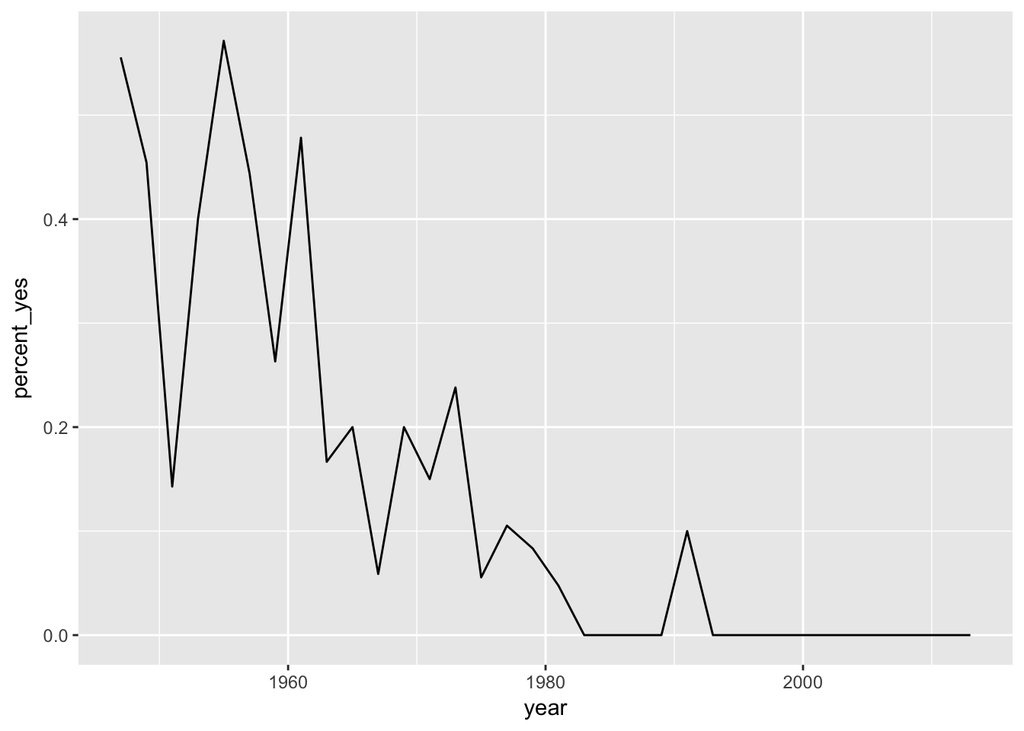

```r
# Load the ggplot2 package
library(ggplot2)

# Filter, then summarize by year: US_co_by_year
US_co_by_year <- votes_joined %>%
  filter(
    co == 1,
    country == "United States"
    ) %>%
  group_by(year) %>%
  summarize(percent_yes = mean(vote == 1))

# Graph the % of "yes" votes over time
ggplot(US_co_by_year, aes(x = year, y = percent_yes)) +
  geom_line()
```

## Tidy data

### – Using gather to tidy a dataset

```r
# Load the tidyr package
library(tidyr)

# Gather the six me/nu/di/hr/co/ec columns
votes_joined %>%
  gather(topic, has_topic, one_of("me","nu","di","hr","co","ec"))
```

```
## # A tibble: 2,121,282 x 10
##     rcid session  vote ccode  year            country       date   unres
##    <dbl>   <dbl> <dbl> <int> <dbl>              <chr>     <dttm>   <chr>
##  1    46       2     1     2  1947      United States 1947-09-04 R/2/299
##  2    46       2     1    20  1947             Canada 1947-09-04 R/2/299
##  3    46       2     1    40  1947               Cuba 1947-09-04 R/2/299
##  4    46       2     1    41  1947              Haiti 1947-09-04 R/2/299
##  5    46       2     1    42  1947 Dominican Republic 1947-09-04 R/2/299
##  6    46       2     1    70  1947             Mexico 1947-09-04 R/2/299
##  7    46       2     1    90  1947          Guatemala 1947-09-04 R/2/299
##  8    46       2     1    91  1947           Honduras 1947-09-04 R/2/299
##  9    46       2     1    92  1947        El Salvador 1947-09-04 R/2/299
## 10    46       2     1    93  1947          Nicaragua 1947-09-04 R/2/299
## # ... with 2,121,272 more rows, and 2 more variables: topic <chr>,
## #   has_topic <dbl>
```

```r
# Perform gather again, then filter
votes_gathered <- votes_joined %>%
  gather(topic, has_topic, one_of("me","nu","di","hr","co","ec")) %>%
  filter(has_topic == 1)
```

### – Recoding the topics

- `recode` is awesome

```r
example <- c("apple", "banana", "apple", "orange")
recode(example,
       apple = "plum",
       banana = "grape")
```

```
## [1] "plum"   "grape"  "plum"   "orange"
```

```r
# Replace the two-letter codes in topic: votes_tidied
votes_tidied <- votes_gathered %>%
  mutate(topic = recode(topic,
                        me = "Palestinian conflict",
                        nu = "Nuclear weapons and nuclear material",
                        di = "Arms control and disarmament",
                        hr = "Human rights",
                        co = "Colonialism",
                        ec = "Economic development"))
```

### – Summarize by country, year, and topic

```r
# Print votes_tidied
votes_tidied
```

```
## # A tibble: 350,032 x 10
##     rcid session  vote ccode  year            country       date    unres
##    <dbl>   <dbl> <dbl> <int> <dbl>              <chr>     <dttm>    <chr>
##  1    77       2     1     2  1947      United States 1947-11-06 R/2/1424
##  2    77       2     1    20  1947             Canada 1947-11-06 R/2/1424
##  3    77       2     3    40  1947               Cuba 1947-11-06 R/2/1424
##  4    77       2     1    41  1947              Haiti 1947-11-06 R/2/1424
##  5    77       2     1    42  1947 Dominican Republic 1947-11-06 R/2/1424
##  6    77       2     2    70  1947             Mexico 1947-11-06 R/2/1424
##  7    77       2     1    90  1947          Guatemala 1947-11-06 R/2/1424
##  8    77       2     2    91  1947           Honduras 1947-11-06 R/2/1424
##  9    77       2     2    92  1947        El Salvador 1947-11-06 R/2/1424
## 10    77       2     1    93  1947          Nicaragua 1947-11-06 R/2/1424
## # ... with 350,022 more rows, and 2 more variables: topic <chr>,
## #   has_topic <dbl>
```

```r
# Summarize the percentage "yes" per country-year-topic
by_country_year_topic <- votes_tidied %>%
  group_by(country, year, topic) %>%
  summarize(
    total = n(),
    percent_yes = mean(vote == 1)
    ) %>%
  ungroup()

# Print by_country_year_topic
by_country_year_topic
```

```
## # A tibble: 26,968 x 5
##        country  year                                topic total
##          <chr> <dbl>                                <chr> <int>
##  1 Afghanistan  1947                          Colonialism     8
##  2 Afghanistan  1947                 Economic development     1
##  3 Afghanistan  1947                         Human rights     1
##  4 Afghanistan  1947                 Palestinian conflict     6
##  5 Afghanistan  1949         Arms control and disarmament     3
##  6 Afghanistan  1949                          Colonialism    22
##  7 Afghanistan  1949                 Economic development     1
##  8 Afghanistan  1949                         Human rights     3
##  9 Afghanistan  1949 Nuclear weapons and nuclear material     3
## 10 Afghanistan  1949                 Palestinian conflict    11
## # ... with 26,958 more rows, and 1 more variables: percent_yes <dbl>
```

### – Visualizing trends in topics for one country

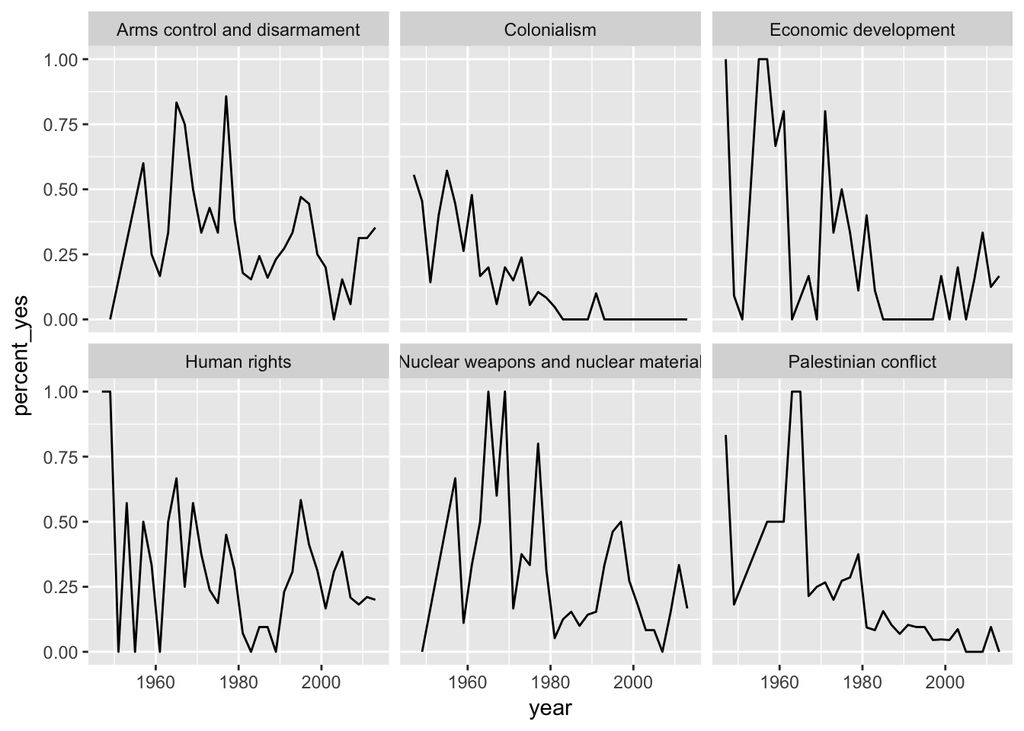

```r
# Load the ggplot2 package
library(ggplot2)

# Filter by_country_year_topic for just the US
US_by_country_year_topic <- by_country_year_topic %>%
  filter(country == "United States")

# Plot % yes over time for the US, faceting by topic
ggplot(US_by_country_year_topic, aes(x = year, y = percent_yes)) +
  geom_line() +
  facet_wrap(~ topic)
```

## Tidy modeling by topic and country

### – Nesting by topic and country

```r
# Load purrr, tidyr, and broom
library(purrr)
library(tidyr)
library(broom)

# Print by_country_year_topic
by_country_year_topic
```

```
## # A tibble: 26,968 x 5
##        country  year                                topic total
##          <chr> <dbl>                                <chr> <int>
##  1 Afghanistan  1947                          Colonialism     8
##  2 Afghanistan  1947                 Economic development     1
##  3 Afghanistan  1947                         Human rights     1
##  4 Afghanistan  1947                 Palestinian conflict     6
##  5 Afghanistan  1949         Arms control and disarmament     3
##  6 Afghanistan  1949                          Colonialism    22
##  7 Afghanistan  1949                 Economic development     1
##  8 Afghanistan  1949                         Human rights     3
##  9 Afghanistan  1949 Nuclear weapons and nuclear material     3
## 10 Afghanistan  1949                 Palestinian conflict    11
## # ... with 26,958 more rows, and 1 more variables: percent_yes <dbl>
```

```r
# Fit model on the by_country_year_topic dataset
country_topic_coefficients <- by_country_year_topic %>%
  nest(-country, -topic) %>%
  mutate(
    model = map(data, ~ lm(percent_yes ~ year, data = .)),
    tidied = map(model, tidy)
    ) %>%
  unnest(tidied)


# Print country_topic_coefficients
country_topic_coefficients
```

```
## # A tibble: 2,383 x 7
##        country                        topic        term      estimate
##          <chr>                        <chr>       <chr>         <dbl>
##  1 Afghanistan                  Colonialism (Intercept)  -9.196506325
##  2 Afghanistan                  Colonialism        year   0.005106200
##  3 Afghanistan         Economic development (Intercept) -11.476390441
##  4 Afghanistan         Economic development        year   0.006239157
##  5 Afghanistan                 Human rights (Intercept)  -7.265379964
##  6 Afghanistan                 Human rights        year   0.004075877
##  7 Afghanistan         Palestinian conflict (Intercept) -13.313363338
##  8 Afghanistan         Palestinian conflict        year   0.007167675
##  9 Afghanistan Arms control and disarmament (Intercept) -13.759624843
## 10 Afghanistan Arms control and disarmament        year   0.007369733
## # ... with 2,373 more rows, and 3 more variables: std.error <dbl>,
## #   statistic <dbl>, p.value <dbl>
```

### – Interpreting tidy models

```r
# Create country_topic_filtered
country_topic_filtered <- country_topic_coefficients %>%
  filter(term == 'year') %>%
  mutate(p.adjusted = p.adjust(p.value)) %>%
  filter(p.adjusted < 0.05)

country_topic_filtered
```

```
## # A tibble: 56 x 8
##                             country                topic  term    estimate
##                               <chr>                <chr> <chr>       <dbl>
##  1                      Afghanistan          Colonialism  year 0.005106200
##  2                          Austria          Colonialism  year 0.008353305
##  3                         Barbados          Colonialism  year 0.006690915
##  4                         Barbados Palestinian conflict  year 0.016588442
##  5                          Belgium          Colonialism  year 0.007313000
##  6 Bolivia (Plurinational State of)          Colonialism  year 0.008524197
##  7                           Brazil          Colonialism  year 0.008271821
##  8                            Chile          Colonialism  year 0.009323302
##  9                         Colombia          Colonialism  year 0.007145088
## 10                       Costa Rica          Colonialism  year 0.007380721
## # ... with 46 more rows, and 4 more variables: std.error <dbl>,
## #   statistic <dbl>, p.value <dbl>, p.adjusted <dbl>
```

### – Steepest trends by topic

- Which combination of country and topic has the steepes downward trend?

```r
country_topic_filtered %>% arrange(estimate)
```

```
## # A tibble: 56 x 8
##          country                                topic  term     estimate
##            <chr>                                <chr> <chr>        <dbl>
##  1       Vanuatu                 Palestinian conflict  year -0.032694090
##  2       Vanuatu                          Colonialism  year -0.017919993
##  3         Malta Nuclear weapons and nuclear material  year -0.011190617
##  4        Cyprus                         Human rights  year -0.010769662
##  5 United States                 Palestinian conflict  year -0.010686324
##  6        Cyprus Nuclear weapons and nuclear material  year -0.010658643
##  7        Israel                          Colonialism  year -0.009529337
##  8       Romania                         Human rights  year -0.009445343
##  9         Malta         Arms control and disarmament  year -0.009299679
## 10        Cyprus         Arms control and disarmament  year -0.008784289
## # ... with 46 more rows, and 4 more variables: std.error <dbl>,
## #   statistic <dbl>, p.value <dbl>, p.adjusted <dbl>
```

- Vanuata on the Palestinian conflict

### – Checking models visually

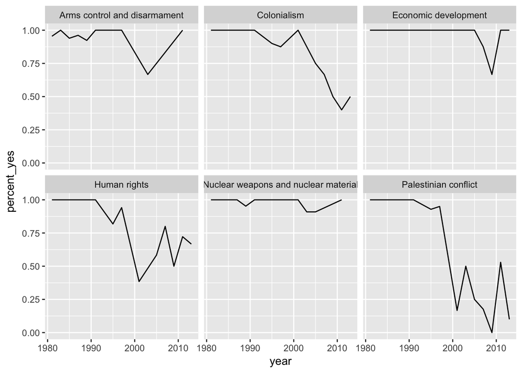

```r
# Create vanuatu_by_country_year_topic
vanuatu_by_country_year_topic <- by_country_year_topic %>%
  filter(country == "Vanuatu")

# Plot of percentage "yes" over time, faceted by topic
ggplot(vanuatu_by_country_year_topic, aes(x = year, y = percent_yes)) +
  geom_line() +
  facet_wrap(~ topic)
```

## Conclusion

- Cool class. I learned some neat tricks.
- It just barely touches the process or working with models in dplyr and broom
- It seems like there could be another class on more advanced modeling and use cases of dplyr and broom.

### – A chart I just wanted to make

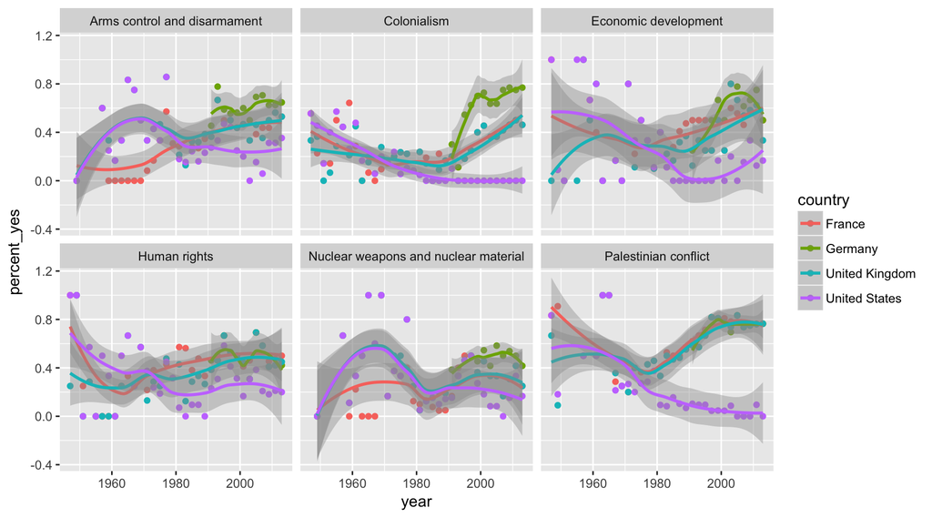

```r
filtered_by_country_year_topic <- by_country_year_topic %>%
  filter(country %in% c("United States", "United Kingdom", "France", "Germany"))

# Plot of percentage "yes" over time, faceted by topic
ggplot(filtered_by_country_year_topic, aes(x = year, y = percent_yes, color = country)) +
  geom_point() +
  geom_smooth() +
  facet_wrap(~ topic)
```